# Analyze disaggregated US CPI data

Philipp Hauber

June 9, 2021

Source: [BLS](https://download.bls.gov/pub/time.series/cu/)

```r
rm(list = ls())
library(dplyr, warn.conflicts = FALSE)
library(tidyr)
library(readxl)
library(openxlsx)
library(stringr)
library(lubridate)
library(ggplot2)
library(ggsci)
options(dplyr.summarise.inform = FALSE) # turn off annoying summarise warning!
```

# Data

## Download CPI series

```r
raw_dat <- read.table("https://download.bls.gov/pub/time.series/cu/cu.data.0.Current", sep="\t", header=TRUE)
df_series <- filter(raw_dat, year >= 2012)
rm(raw_dat)
```

Convert month to numeric variables and keep only monthly observations (discarding semi-annual and annual CPI levels)

```r
df_series %>%
  separate(period, into = c("tmp", "month"), sep = 1) %>%
  filter(tmp == "M") %>%
  select(-tmp, -footnote_codes) %>%
  mutate(month = as.numeric(month),
         date = make_date(year = year, month = month)) %>%
  select(-year, -month) -> df_series
```

Split `series_id` into series code, filter `area` for **All city average** and `sa` for seasonally adjusted data **S**

```r
df_series %>%
  separate(series_id,
           into = c("tmp", "sa", "periodicity", "area", "series"),
           sep = c(2,3,4,8)
           ) %>%
  filter(area == "0000",
         periodicity == "R") %>%
  mutate(series = str_trim(series)) %>%
  select(-tmp, -area) %>%
  drop_na() -> df_series
```

Filter for seasonally adjusted data - **S** - except personal care products (SEGB) where only unadjusted data - **U** - are available

```r
ind_keep <- df_series$sa == "S"
ind_keep[df_series$series == "SEGB"] <- TRUE
df_series <- df_series[ind_keep, ]

rm(ind_keep)
```

Remove some columns and reorder the rest

```r
df_series <- select(df_series, date, series, value)
```

## Download names of CPI series

[Link to series names](https://download.bls.gov/pub/time.series/cu/cu.item)

```r
raw_names <- read.table(file = "https://download.bls.gov/pub/time.series/cu/cu.item", sep = "\t", header=T, stringsAsFactors = F, quote = "")

df_names <- select(raw_names, item_code, item_name, display_level)

rm(raw_names)
```

Merge names with series in `df`

```r
df <- merge(df_series, df_names, by.x = "series", by.y = "item_code")
df <- rename(df, name = item_name)
rm(df_names, df_series)

filter(df, name == "Personal care products")
```

| series | date | value | name | display_level |
| --- | --- | --- | --- | --- |
| SEGB | 2012-01-01 | 161.256 | Personal care products | 2 |
| SEGB | 2012-02-01 | 160.616 | Personal care products | 2 |
| SEGB | 2012-03-01 | 162.620 | Personal care products | 2 |
| SEGB | 2012-04-01 | 163.147 | Personal care products | 2 |
| SEGB | 2012-05-01 | 161.538 | Personal care products | 2 |
| SEGB | 2012-06-01 | 162.079 | Personal care products | 2 |
| SEGB | 2012-07-01 | 162.390 | Personal care products | 2 |
| SEGB | 2012-08-01 | 163.072 | Personal care products | 2 |
| SEGB | 2012-09-01 | 163.135 | Personal care products | 2 |
| SEGB | 2012-10-01 | 162.697 | Personal care products | 2 |

[output cut: 103 more lines]

Filter out those series for which there are missing observations, i.e. the total number of observations is not equal to the nummber of observations available for the headline index!

```r
n_obs_all_items <- sum(df$name == "All items")

df %>% group_by(name) %>% summarise(n_obs = n()) %>% filter(n_obs == n_obs_all_items) -> list_keep

df <- filter(df, name %in% list_keep$name)

rm(list_keep)
```

## Download weights of CPI series

Define a function to transform the raw, downloaded weights and

- change column names
- remove single- and double-digit footnotes from `name`
- convert weights to numeric, level to integer (and factor)
- remove `NA`, blank lines

```r
transform_raw_weights <- function(raw_data)
{
  ind_start <- grep("All items", raw_data[, 2])[1]
  df <- raw_data[seq(ind_start, nrow(raw_data)), seq(1, 3)]

  names(df) <- c("level", "name", "weight")
  df %>%
    mutate(level = factor(as.integer(level)),
           weight = as.numeric(weight),
           name = sapply(name, gsub, pattern = "\\(.\\)", replacement = ""),
           name = sapply(name, gsub, pattern = "\\(..\\)", replacement = "")) %>%
    filter(!is.na(weight)) -> df

  return(df)
}
```

### Weights for December 2020

The relative importance of the different items for December 2020 can be found in the Supplemental Tables of the January 2021 release

```r
url <- "https://www.bls.gov/cpi/tables/supplemental-files/news-release-table2-202101.xlsx"
fn <- "cpi_weights.xlsx"
download.file(url = url , destfile = fn, mode = "wb")
```

```
versuche URL 'https://www.bls.gov/cpi/tables/supplemental-files/news-release-table2-202101.xlsx'
```

```r
raw_weights <- read_excel(path = fn)
```

```
* `` -> ...1
* `` -> ...3
* `` -> ...4
* `` -> ...5
* `` -> ...6
* ...
```

```r
file.remove(fn)
```

```
[1] TRUE
```

```r
raw_weights %>%
  transform_raw_weights() %>%
  mutate(year = "2020") %>%
  rename(weight_Dec = weight) %>%
  select(-level)-> df_weights_Dec
```

```
Problem with `mutate()` input `level`.
i NAs durch Umwandlung erzeugt
i Input `level` is `factor(as.integer(level))`.NAs durch Umwandlung erzeugtProblem with `mutate()` input `weight`.
i NAs durch Umwandlung erzeugt
i Input `weight` is `as.numeric(weight)`.NAs durch Umwandlung erzeugt
```

```r
rm(raw_weights, fn, url)
```

### Weights for December 2019

The relative importance of the different items for December 2019 can be found in the Supplemental Tables of the January 2020 release

```r
url <- "https://www.bls.gov/cpi/tables/supplemental-files/news-release-table2-202001.xlsx"
fn <- "cpi_weights.xlsx"
download.file(url = url , destfile = fn, mode = "wb")
```

```
versuche URL 'https://www.bls.gov/cpi/tables/supplemental-files/news-release-table2-202001.xlsx'
```

```r
raw_weights <- read_excel(path = fn)
```

```
* `` -> ...1
* `` -> ...3
* `` -> ...4
* `` -> ...5
* `` -> ...6
* ...
```

```r
file.remove(fn)
```

```
[1] TRUE
```

```r
raw_weights %>%
  transform_raw_weights() %>%
  mutate(year = "2019") %>%
  rename(weight_Dec = weight) %>%
  select(-level) %>%
  rbind(df_weights_Dec) -> df_weights_Dec
```

```
Problem with `mutate()` input `level`.
i NAs durch Umwandlung erzeugt
i Input `level` is `factor(as.integer(level))`.NAs durch Umwandlung erzeugtProblem with `mutate()` input `weight`.
i NAs durch Umwandlung erzeugt
i Input `weight` is `as.numeric(weight)`.NAs durch Umwandlung erzeugt
```

```r
rm(raw_weights, fn, url)
```

### Weights for December 2012-2018

The relative importance of the different items for December 2012-2019 can be found in the Supplemental Tables of the January release of the following year(e.g. 2019 for 2018). Note, however, that the files for 2019 and earlier have been archived and need to be downloaded and unzipped first!

```r
for (year_weights in c(2012:2018))
{
url <- paste0("https://www.bls.gov/cpi/tables/supplemental-files/archive-", year_weights+1, ".zip")
download.file(url = url, destfile = paste0("tmp", year_weights+1, ".zip"))
list_dir_old <- list.dirs()
unzip(paste0("tmp", year_weights+1, ".zip"))
dir_in <- setdiff(list.dirs(), list_dir_old)
if (year_weights + 1 >= 2017)
  raw_weights <- read.xlsx(paste0(dir_in, "/news-release-table2-", year_weights+1, "01.xlsx"))
else
{
  if (file.exists(paste0(dir_in, "/CpiPress2_FINAL_", year_weights+1, "01.xlsx"))) # try xlsx
    raw_weights <- read.xlsx(paste0(dir_in, "/CpiPress2_FINAL_", year_weights+1, "01.xlsx"))
  else
    raw_weights <- read_excel(paste0(dir_in, "/CpiPress2_FINAL_", year_weights+1, "01.xls"))
}

file.remove(paste0("tmp", year_weights+1, ".zip"))
unlink(dir_in, recursive = T, force = T)

raw_weights %>%
  transform_raw_weights() %>%
  mutate(year = !!year_weights) %>%
  rename(weight_Dec = weight) %>%
  select(-level) %>%
  rbind(df_weights_Dec) -> df_weights_Dec
}
```

[output not shown]

```r
#rm(raw_weights, url)
```

### Calculate weights for all months and series

[Details on how to calculate the weights](https://www.bls.gov/cpi/tables/relative-importance/home.htm)

```r
df_weights <- data.frame()

# function to calculate ratio of index
ratio_of_index <- function(value, date, date1, date2)
  return(value[which(date == date2)] / value[which(date == date1)])
dates <- seq(as_date("2012-12-01"), as_date("2021-04-01"), by = "month") # calculate the weights for Jan12-May21!
for (ind_d in seq(1, length(dates)))
{
  d <- dates[ind_d]
  if (month(d) == 12) # no need to calculate weights for December!
          df_weights_Dec %>%
            filter(year == year(d)) %>%
            select(-year, weight = weight_Dec) %>%
            mutate(date = d + months(1)) %>%
            rbind(df_weights) -> df_weights
  else
  {
          d_base <- make_date(year = year(d) - 1, month = 12)

          df_tmp <- merge(df, filter(df_weights_Dec, year == year(d_base)), by = "name")

          df_tmp %>%
            filter(name == "All items") %>%
            summarise(change_all = ratio_of_index(value, date, d_base, d)) %>%
            select(change_all) -> change_all

          df_tmp %>%
            filter(name != "All items") %>%
            group_by(name, weight_Dec) %>%
            summarise(change_series = ratio_of_index(value, date, d_base, d)) %>%
            mutate(new_weight = change_series * weight_Dec,
                   new_weight_normalized = new_weight / change_all[1,1]) %>%
            ungroup() %>%
            select(name, weight = new_weight_normalized) %>%
            mutate(date = d + months(1)) %>%
            rbind(df_weights) -> df_weights

          # add All items which was filtered out above
          df_weights <- rbind(df_weights, data.frame(name = "All items", weight = 100.0, date = d + months(1)))
  }
}

#rm(df_tmp, df_weights_Dec, change_all, d, d_base, ind_d, dates)
rm(df_tmp,  change_all, d, d_base, ind_d, dates)
```

Merge with `left_join()` (this keeps the observations for which we have no weights)

```r
df <- left_join(df, df_weights, by = c("name", "date"))
```

## Download categories and levels (food, goods, services, energy)

```r
url <- "https://www.bls.gov/cpi/tables/supplemental-files/news-release-table2-202104.xlsx"
fn <- "cpi_weights.xlsx"
download.file(url = url , destfile = fn, mode = "wb")
```

```
versuche URL 'https://www.bls.gov/cpi/tables/supplemental-files/news-release-table2-202104.xlsx'
```

```r
raw_table2_apr2021 <- read_excel(path = fn)
```

```
* `` -> ...1
* `` -> ...3
* `` -> ...4
* `` -> ...5
* `` -> ...6
* ...
```

```r
file.remove(fn)
```

```
[1] TRUE
```

```r
raw_table2_apr2021 %>%
  transform_raw_weights() %>%
  select(-weight) -> df_categories
```

```
Problem with `mutate()` input `level`.
i NAs durch Umwandlung erzeugt
i Input `level` is `factor(as.integer(level))`.NAs durch Umwandlung erzeugtProblem with `mutate()` input `weight`.
i NAs durch Umwandlung erzeugt
i Input `weight` is `as.numeric(weight)`.NAs durch Umwandlung erzeugt
```

```r
df_categories$category <- "Goods"

start_food <- which(df_categories$name == "Food")
end_food <- which(df_categories$name == "Other food away from home")
df_categories$category[seq(start_food, end_food)] <- "Food"

start_energy <- which(df_categories$name == "Energy")
end_energy <- which(df_categories$name == "Utility (piped) gas service")
df_categories$category[seq(start_energy, end_energy)] <- "Energy"

start_services <- which(df_categories$name == "Services less energy services")
end_services <- which(df_categories$name == "Financial services")
df_categories$category[seq(start_services, end_services)] <- "Services"

df_categories$category[df_categories$name == "All items"] <- "Total"
df_categories$category[df_categories$name == "All items less food and energy"] <- "Total ex energy and food"

rm(raw_table2_apr2021, end_energy, end_food, end_services, start_energy, start_food, start_services, fn, url)
```

The `level` from the Supplemental Table does not match with `display_level` from the raw series. However, as I am unsure what the latter actually refers to, I discard it.

Merge with `df` and reorder columns

```r
df <- left_join(df, df_categories, by = "name")
df <- select(df, date, series, name, value, weight, category, level)
rm(df_categories)
```

# Analysis

## Auxiliary functions

```r
growth_rate <- function(x, dates, date1, date2)
#calculate growth rate of the CPI index between y1m1 and y2m2
{
  ind1 <- which(dates == date1)
  ind2 <- which(dates == date2)
  return(x[ind2] / x[ind1] * 100 - 100)
}
```

```r
rebase_index <- function(x, dates, date0)
# rebase index to 100 in y0m0
{
  ind0 <- which(dates == date0)
  return(x / x[ind0] * 100)
}
```

## Plot CPI index

Index for different components

- Food
- Energy
- Services (ex energy)
- Durables
- Non-durables (ex food and energy)

### Construct non-durables ex energy and food

#### Non-durables

```r
list_ndurables <- c("Apparel",
                   "Window and floor coverings and other linens",
                   "Housekeeping supplies",
                   "Medical care commodities",
                   "Audio discs, tapes and other media",
                   "Unsampled video and audio",
                   "Pets and pet products",
                   "Photographic equipment and supplies",
                   "Recreational reading materials",
                   "Other recreational goods",
                   "Educational books and supplies",
                   "Tobacco and smoking products",
                   "Personal care products",
                   "Miscellaneous personal goods")
```

Which of these items are not in the data?

```r
tmp <- filter(df, name %in% list_ndurables)
setdiff(list_ndurables, tmp$name)
```

```
[1] "Audio discs, tapes and other media" "Unsampled video and audio"
```

```r
rm(tmp)
```

```r
df %>%
  filter(name %in% list_ndurables) %>%
  group_by(date) %>%
  mutate(sum_weights = sum(weight)) %>%
  group_by(name) %>%
  mutate(value_rebased = rebase_index(value, date, "2020-02-01")) %>%
  ungroup() %>%
  mutate(weights_normalized = weight/sum_weights) %>%
  group_by(date, sum_weights) %>%
  summarise(index = sum(value_rebased * weights_normalized)) %>%
  mutate(group = "Non-durables",
         weight = sum_weights) -> df_ndurables
```

#### Durables

Items belonging to **durables** according to correspondence with BLS

```r
list_durables <- c("Furniture and bedding",
                   "Appliances",
                   "Other household equipment and furnishings",
                   "Tools, hardware, outdoor equipment and supplies",
                   "New vehicles",
                   "Used cars and trucks",
                   "Unsampled new and used motor vehicles",
                   "Motor vehicle parts and equipment",
                   "Televisions",
                   "Other video equipment",
                   "Audio equipment",
                   "Sporting goods",
                   "Information technology commodities")
```

Which of these items are not in the data?

```r
tmp <- filter(df, name %in% list_durables)
setdiff(list_durables, tmp$name)
```

```
[1] "Unsampled new and used motor vehicles"
```

```r
rm(tmp)
```

```r
df %>%
  filter(name %in% list_durables) %>%
  group_by(date) %>%
  mutate(sum_weights = sum(weight)) %>%
  group_by(name) %>%
  mutate(value_rebased = rebase_index(value, date, "2020-02-01")) %>%
  ungroup() %>%
  mutate(weights_normalized = weight/sum_weights) %>%
  group_by(date, sum_weights) %>%
  summarise(index = sum(value_rebased * weights_normalized)) %>%
  mutate(group = "Durables",
         weight = sum_weights) -> df_durables
```

#### Durables, energy, food and services ex energy

```r
df %>%
  filter(name %in% c("Services less energy services",
                     "Food at home",
                     "Food away from home",
                     "Energy",
                     "Durables")
         )%>%
  rename(group = name) %>%
  group_by(group) %>%
  mutate(index = rebase_index(value, date, "2020-02-01")) -> df_others
```

### Merge dataframes and plot

```r
#df_groups <- rbind(df_others, rbind(df_durables, df_ndurables))
df_groups <- rbind(df_others, df_ndurables)
```

```r
df_groups %>%
  group_by(date) %>%
  summarise(sum_weight = sum(weight))
```

| date | sum_weight |
| --- | --- |
| 2012-01-01 | NA |
| 2012-02-01 | NA |
| 2012-03-01 | NA |
| 2012-04-01 | NA |
| 2012-05-01 | NA |
| 2012-06-01 | NA |
| 2012-07-01 | NA |
| 2012-08-01 | NA |
| 2012-09-01 | NA |
| 2012-10-01 | NA |

[output cut: 103 more lines]

Plot series

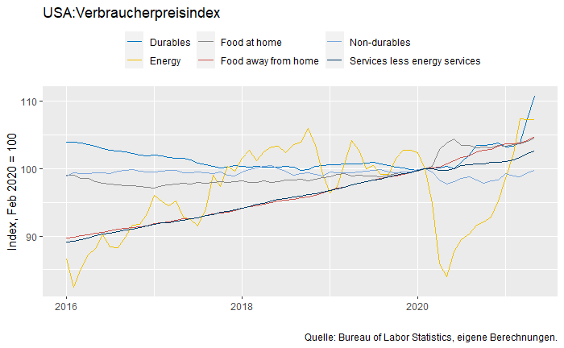

```r
df_groups %>%
  filter(date >= "2016-01-01") %>%
  ggplot(aes(x = date, y = index, color = group, group = group))+
  geom_line()+
  scale_color_jco()+
  labs(x = "", y = "Index, Feb 2020 = 100",
       title = "USA:Verbraucherpreisindex",
       caption = "Quelle: Bureau of Labor Statistics, eigene Berechnungen.")+
  theme(legend.title = element_blank(),
        legend.position = "top")
```

```r
#ggsave(filename = "plot_cpi_US_20162021.pdf", width = 12, height = 6, units = "in")
```

### Export to csv

```r
df_groups %>%
  filter(date >= "2016-01-01") %>%
  select(date, group, index) %>%
  pivot_wider(names_from = "group", values_from = "index") %>%
  write.xlsx(file = "data_cpi.xlsx", sheetName = "Sheet1",
  col.names = TRUE, row.names = TRUE, append = FALSE)
```

## Plot contributions of categories to m/m change

This part of the analysis does not work while there are no weights for durables. In any vase, as I cannot replicate the exact weights and subcomponents non-durables ex energy, the m/m rates might be off by a bit. Therefore, it seems more reasonable to focus less on the details of monthly changes and use the index to convey the main message.

```r
# df_mm <- data.frame()
#
# yys <- c(2020:2021)
# mms <- c(1:12)
#
# for (yy in yys){
#   for (mm in mms){
#             if (yy == 2021 && mm > 5)
#                break
#
#             #if (yy == 2020 && mm == 1)
#             #  next
#
#
#             if (mm == 1){
#               yy_prev <- yy-1
#               mm_prev <- 12
#             } else {
#               yy_prev <- yy
#               mm_prev <- mm - 1
#             }
#
#             df_groups %>%
#               group_by(group) %>%
#               mutate(mm_growth = growth_rate(index,
#                                              date,
#                                              make_date(year = yy_prev, month = mm_prev),
#                                              make_date(year = yy, month = mm)
#                                              ),
#                      ) %>%
#               filter(date == make_date(year = yy, month = mm)) %>%
#               select(date, group, mm_growth, weight, category) %>%
#               mutate(mm_growth_weighted = mm_growth * weight / 100) %>%
#               ungroup() %>%
#               rbind(df_mm) -> df_mm
#   }
# }
```

```r
# df_mm %>%
#   ggplot(aes(x = date, y = mm_growth_weighted, group = group, fill = group))+
#   geom_col(position = 'stack')+
#   scale_fill_jco()
```

```r
# df_mm %>%
#   filter(name != "All items") %>%
#   ggplot(mapping = aes(x = date, y = mm_growth_weighted, group = name, fill = category),
#          data = filter(df_mm, name != "All items"))+
#   geom_col(position = 'stack')+
#   scale_fill_jco()+
#   geom_line(mapping = aes(x = date, y = mm_growth),
#             data = filter(df_mm, name == "All items"),
#             color = "black", show.legend = FALSE)+
#   geom_point(mapping = aes(x = date, y = mm_growth),
#             data = filter(df_mm, name == "All items"),
#             color = "black", show.legend = FALSE)
```

### Compare sum of weighted components with headline m/m growth

```r
# df_mm %>% filter(name != "All items") %>% group_by(date) %>% summarise(sum_components = sum(mm_growth_weighted)) %>% select(date, sum_components) %>% merge(filter(df_mm, name == "All items"), by = "date") %>% select(sum_components, mm_growth) %>% round(digits = 2)
```

## m/m changes in April and May 2021 vs. differences to pre-pandemic level for selected goods and services

```r
df %>%
  group_by(name, category) %>%
  summarise(value_mm = growth_rate(value, date, "2021-04-01", "2021-05-01")) %>%
  mutate(date = as_date("2021-05-01")) %>%
  select(name, date, value_mm, category)-> tmp

df %>%
  group_by(name, category) %>%
  summarise(value_mm = growth_rate(value, date, "2021-03-01", "2021-04-01")) %>%
  mutate(date = as_date("2021-04-01")) %>%
  select(name, date, value_mm, category) %>% rbind(tmp) -> tmp

tmp2 <- merge(tmp, select(df, name, date, weight), by = c("name", "date"))

df %>%
  group_by(name, category) %>%
  summarise(diff_pandemic = growth_rate(value, date, "2020-02-01", "2021-03-01")) %>%
  select(name, diff_pandemic)-> tmp

tmp3 <- merge(tmp2, tmp, by = "name")

tmp3$date_str <- "May 21"
tmp3$date_str[tmp3$date == as_date("2021-04-01")] <- "Apr 21"
```

### Plot

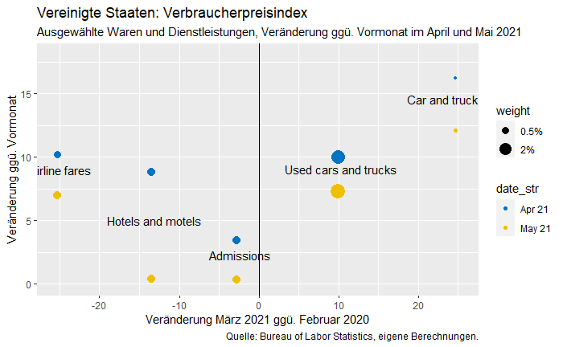

```r
tmp3 %>%
  filter(name %in% c("Car and truck rental",
                     "Airline fares",
                     "Used cars and trucks",
                     #"New vehicles",
                     "Admissions",
                     "Other lodging away from home including hotels and motels")) -> df_plot

df_plot$name <- ifelse(df_plot$name == "Other lodging away from home including hotels and motels", "Hotels and motels", df_plot$name)

df_plot %>% group_by(name, diff_pandemic) %>%
  summarise(y_coord = mean(value_mm)) %>%
  select(name, x_coord = diff_pandemic, y_coord) -> df_text

df_plot %>%
ggplot(aes(x = diff_pandemic, y = value_mm))+
  geom_point(aes(color = date_str, size = weight))+
  scale_color_jco()+
  ylim(c(0, 18))+
  scale_size(breaks = c(0.1, 0.5, 2), labels = c("0.1%", "0.5%", "2%"))+
  labs(title = "Vereinigte Staaten: Verbraucherpreisindex",
       subtitle = "Ausgewählte Waren und Dienstleistungen, Veränderung ggü. Vormonat im April und Mai 2021",
       caption = "Quelle: Bureau of Labor Statistics, eigene Berechnungen.",
       y="Veränderung ggü. Vormonat",
       x = "Veränderung März 2021 ggü. Februar 2020")+
  geom_vline(xintercept = 0)+
  geom_text(mapping = aes(x = x_coord, y = y_coord, label = name),
            data = df_text,
            size = 4,
            nudge_x = 0.4,
            nudge_y = 0.4)
```

```r
NA
```

```r
#ggsave(filename = "plot_cpi_US_apr21may21.pdf", width = 12, height = 6, units = "in")
```

### Export to csv

```r
df_plot %>%
  select(name, date_str, diff_pandemic, value_mm) %>%
  pivot_wider(names_from = "date_str", values_from = "value_mm") %>%
  write.xlsx(file = "data_CPI_AprMay21.xlsx", sheetName = "Sheet1",
  col.names = TRUE, row.names = TRUE, append = FALSE)
```

### Calculations

- average weight in April and May 2021

```r
df_plot %>%
  select(name, weight) %>%
  group_by(name) %>%
  summarise(mean_weight = round(mean(weight), digits = 1))
```

| name | mean_weight |
| --- | --- |
| Admissions | 0.7 |
| Airline fares | 0.6 |
| Car and truck rental | 0.2 |
| Hotels and motels | 0.7 |
| Used cars and trucks | 2.8 |

- Contribution of the categories above to the total price increase in April and May (`sum_mm_weighted`)
- their combined weight in the goods basket (`sum_weight`)

```r
df_plot %>%
  mutate(mm_weighted = value_mm * weight/100) %>%
  group_by(date) %>%
  summarise(sum_mm_weighted = sum(mm_weighted),
            sum_weight = sum(weight))
```

| date | sum_mm_weighted | sum_weight |
| --- | --- | --- |
| 2021-04-01 | 0.4371624 | 4.778035 |
| 2021-05-01 | 0.2852552 | 5.175345 |

- total increase in the CPI in April and May

```r
df %>%
  filter(name == "All items") %>%
  summarise(mmApr21 = growth_rate(value, date, "2021-03-01", "2021-04-01"),
            mmMay21 = growth_rate(value, date, "2021-04-01", "2021-05-01"))
```

| mmApr21 | mmMay21 |
| --- | --- |
| 0.7700355 | 0.6442256 |